# Problem set 2: Problem set training

Colleen Cronin

August 31, 2023

## Overview

Always start by knitting the rmd file (Ctrl/Cmd + shift + k). This converts the markdown to an html file that you can view in your Viewer pane. The html that is generated when you knit a file is much easier to read than the markdown file)!

[figure not shown]

*Luke Skywalker found creative ways to train for a notoriously difficult course on GIS in R.*

My problem sets have a reputation for being pretty difficult. Here, I intend to train you on how to complete them with as little pain as possible (and with minimal points taken off). “Training” tips and tricks will be shared in a gray box with a spy icon (; *as above*). Portions of this problem set in which user input is required are highlighted in a blue box with a dark blue border on the left.

### About the data

This problem set will use `district_birds.rds`, a tidy dataset that contains a subset of records from the Smithsonian Migratory Bird Center’s [Neighborhood Nestwatch](https://nationalzoo.si.edu/migratory-birds/neighborhood-nestwatch) (NN) program. NN is a community science project where scientists visits backyards, neighborhoods, and schools to conduct bird banding demonstrations and sample bird populations. The data include tables for sites, visits, point counts, and capture events, and a table that provides natural history information for observed birds. Geographic coordinate values have been jittered to protect the privacy of NN participants.

In this lesson, we will only be working only with the `capture` dataset. These data describe information collected when a wild bird has been captured and released. Variables in this table include:

- `capture_id` (character): The primary key of the table;
- `visit_id` (character): A foreign key to the `visits` table;
- `band_number` (character): A unique numeric identifier for an aluminum band placed on a bird;
- `color_combo` (character): A combination of color bands that are added to some birds for quick identification of individuals;
- `spp` (character): A four-letter code for the species banded (see the `birds` table)
- `sex` (character): The sex of the bird (F = female, M = male, U = unknown);
- `age` (character): A code for the age class of the bird (e.g., HY = “Hatch year”, AHY = “After hatch year”);
- `wing` (numeric, double): The length of a bird’s wing, in millimeters;
- `tl` (numeric, double): The length of a bird’s tail, in millimeters;
- `mass` (numeric, double): The mass of the bird, in grams;
- `bp_cp` (character): A code for the breeding condition of a bird (bp = “brood patch”, cp = “cloacal protuberance”);
- `fat` (character): An ordinal code for how much fat the bird is carrying.

I **strongly recommend** working in two files as you complete problem sets – an R script file and the R Markdown file. When you have completed the assigned questions, copy-and-paste your code into this R Markdown file, where prompted.

## Grading

The points allotted for each question are provided in highlighted red bold text (e.g., [1.0]) within the question itself. When applicable, total points for a question may represent the sum of individually graded components, which are provided in red text (e.g., [1.0]).

Points may be deducted from each question’s total:

- [50% per violation] Use only functions listed in “Functions that you may use in this assignment”;
- [50%] Include only assignments specified in the question;
- [10%] Ensure that all code is properly indented;
- [10%] Ensure that your code follows modern coding conventions (see *Best practices in modern R coding*);
- [10%] Ensure that all code chunks are formatted as `eval = TRUE` (but see below);
- [10%] Ensure that the class of your response is consistent with the wording of the question (e.g., if you are asked to return a “value” or “vector”, ensure that the resultant object is not a data frame).

*Note: The maximum deduction is the total points value for a given question*

Pay careful attention to the format of your code – not following the rules above will cost you lots of little points (and some big ones) that can really add up!

In addition to points allotted per question, you must ensure that your R Markdown document **runs out-of-the-box** [25% off of the total grade] – in other words, the document will knit without error. Some tips for doing so:

- Do not maintain your project folder in a location that is backed up by an online directory (e.g., Dropbox, iCloud).
- Ensure that all file paths are equivalent to those in this document (e.g., in `source()` or `read_csv()`).
- Do not use `setwd()` in your code (**Never** use `setwd()`!)
- If one of your code chunks contains an error, include `eval = FALSE` in the options for that chunk. Otherwise, ensure all of your code chunks options are `eval = TRUE`.
- Prior to submission, clear all objects from your global environment and try to knit your document again.

Click the blue button below to view the functions that you may use in completing this problem set. Make sure that you know what each function does (use `?[function name]` if you do not). Do not use any functions outside of this list!

In this assignment, you may use **only** the following R functions:

- base::()
- base::=
- base::==
- base::!
- base::!=
- base::%in%
- base::c
- base::is.na
- base::library
- base::list2env
- base::mean
- base::median
- dplyr::filter
- dplyr::n
- dplyr::pull
- dplyr::select
- dplyr::summarize
- ggplot2::aes
- ggplot2::coord_flip
- ggplot2::element_blank
- ggplot2::element_line
- ggplot2::geom_boxplot
- ggplot2::ggplot
- ggplot2::scale_y_continuous
- ggplot2::theme
- knitr::kable
- magrittr::%>%
- readr::read_rds
- tidyr::drop_na
- tidyr::pivot_longer

## Getting started (gimme questions)

Remember that it’s best practice to start with a clean R Studio session (i.e., close any script files, remove objects from your global environment, and clear your history).

I always start my assignments off with some easy points for naming your file, providing your name and the date, and loading any necessary libraries.

1. [1.0] Save this document to your project folder with naming convention “problem_set_2_[Last name]_[First name].rmd”. For example, I would name my file `problem_set_2_Evans_Brian.rmd`.

Be very careful with the naming convention of your file and follow the instructions to-the-letter!

2. [0.25] Provide your name and the current date in the YAML header.

3. [0.25] Load the tidyverse library:

```r
library(tidyverse)
```

Replace “`# Your answer here`” with the code you used to load the tidyverse library. You may find that other libraries are needed to complete this problem set – if this is the case, call a function from that package rather than loading the full library (e.g., `dplyr::mutate()`).

## Straightforward questions

After you have completed the first round of gimme questions, the next set of questions that you will address are pretty straightforward – they are *nearly* identical to coding steps that you have taken when completing the videos or tutorials. These will make up the bulk of the questions in most problem sets.

For example …

4. [0.25] The data file `district_birds.rds` is structured as a list object. As parsimoniously as possible, modify the below by assigning the names of each of the individual list items to the global environment.

```r
read_rds("data/raw/district_birds.rds") %>%
  list2env(envir = .GlobalEnv)
```

```
## <environment: R_GlobalEnv>
```

It pays to keep track of when a function was first used (or used elsewhere in new ways). The answer to the above question was covered in the tutorial “Reshaping data frames” (“Data for this lesson”), and subsequently in the video lessons “Tidy data” (12:56), and “Mutation” (1:34). Note that the latter two applications may be more useful in answering this question, as we’d not yet learned pipes when you completed “Reshaping data frames”.

You can typically recognize a straightforward question, because they will almost directly reflect a process that you completed during one of the video sessions. For example, we covered converting nested versions of chained analyses to piped versions in the video on pipes (6:26-11:22) and in the tutorial “The pipe compendium” (see section “the pipe”). You can apply these examples (almost directly) to address the following question.

5. [0.75] The code block below uses a nested coding structure to calculate the average mass of American robins (“AMRO”). Replace the below with a code block in which each step in the process is connected by a pipe.

```r
captures %>%
  filter(spp == "AMRO") %>%
  pull (mass) %>%
  mean(na.rm = TRUE)
```

```
## [1] 75.09366
```

The “straightforward questions” typically ask you to dig into the material that you’ve been provided. The goal of these questions is largely for you to be able to self-assess your understanding of the material that we perceive to be especially important. For example, I’m really a fan of adhering to “best practices in R coding” …

6. [1.5] The code block below generates a box plot that illustrates the distribution of bird mass by species. Modify the code block such that it follows the conventions in the “Best Practices … document” (*Hint: There are six violations total*).

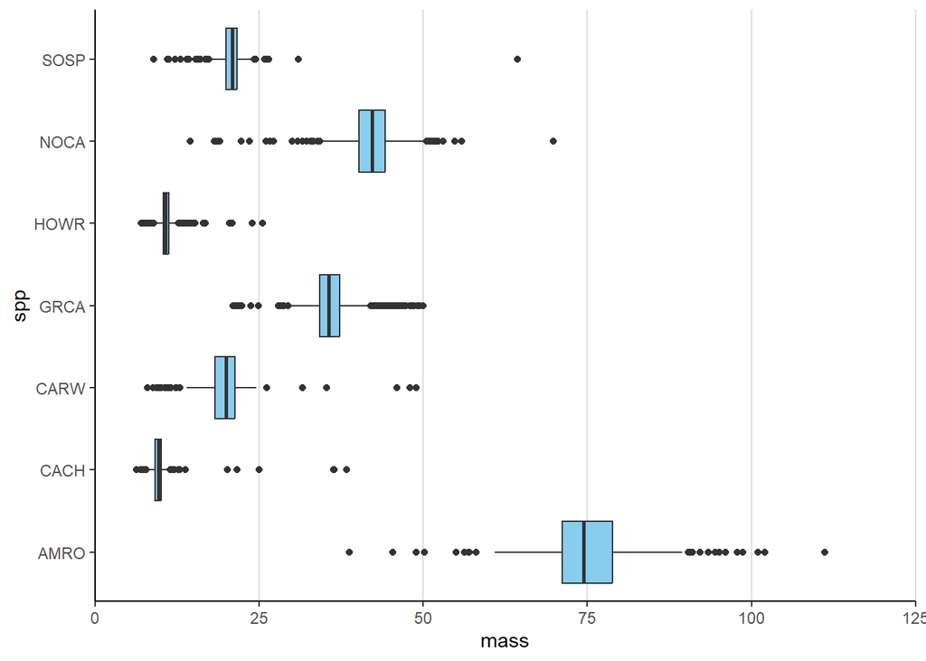

```r
captures %>%

  # Remove NA values:

  drop_na(mass) %>%

  # Subset to birds with at least 100 mass measurements:

  filter(
    n() >= 100,
    .by = spp) %>%

  # Initiate plot:

  ggplot() +

  # Define aesthetics and geometry:

  aes(x = spp, y = mass) +
  geom_boxplot(fill = "#88ccee") +

  # Define scale:

  scale_y_continuous(
    limits = c(0, 125),
    expand = c(0, 0)) +

  # Flip axes:

  coord_flip() +

  # Define theme:

  theme(
    panel.background = element_blank(),
    axis.line = element_line(color = "black"),
    panel.grid.major.x = element_line(color = "#dcdcdc"))
```

This is not to say that “straightforward questions” are entirely paint-by-numbers. Straightforward questions *may* pull from multiple lessons. For example, the following draws from the *Tidyverse addendum* document, the filtering lesson (15:50-16:00; 16:38-18:36), and *Lesson two: Values, 4.0 Logical values* from the pre-course content.

7. [1.5] The code block below attempts to provide summary statistics describing the mass of three bird species (Gray catbird: “GRCA”, Northern Cardinal: “NOCA”, Song sparrow: “SOSP”). The goal is to generate a kable table with a row for each species and the columns spp, n_birds, median_mass, and mean_mass. Unfortunately, there are errors (3 of them) in the code – please fix them!

```r
captures %>%
  filter(
    spp %in% c("GRCA", "NOCA", "SOSP"),
   !is.na(mass)) %>%
  summarize(
    .by = spp,
    n_birds = n(),
    median_mass = median(mass),
    mean_mass = mean(mass)) %>%
  knitr::kable()
```

| spp | n_birds | median_mass | mean_mass |
| --- | --- | --- | --- |
| SOSP | 515 | 20.9 | 20.76449 |
| GRCA | 1284 | 35.6 | 36.00024 |
| NOCA | 1264 | 42.2 | 42.17087 |

## Integrated questions

While the goals of the “straightforward question” are to get you to read the material carefully and examine your ability to understand the material as it was presented, the goal of the integrated question goes a bit further. Here, we seek to assess whether you are able to *integrate* content that you’ve learned across multiple lessons.

For example, the next question calls on your understanding of conducting chained analyses with pipes *and* your understanding of what the functions in the provided code block are doing.

8. [1.5] The code chunk below generates a kable table to describe the average mass of male and female Gray catbirds (spp = “GRCA”). This is completed in a series of steps and uses global assignments to store the results of each step in the process. Convert this to a single code block in which:

- [0.5] There are no global assignments;
- [0.5] Each step in the process is connected by a pipe;
- [0.5] The number of functions are reduced to just those necessary to generate the desired output.

```r
captures %>%
  filter(
    spp == "GRCA",
    sex %in% c("M", "F")) %>%
  select(sex, mass) %>%
  drop_na(mass) %>%
  summarize(
    mass = mean(mass),
    .by = sex) %>%
knitr::kable()
```

| sex | mass |
| --- | --- |
| M | 35.45729 |
| F | 37.44368 |

The above examines your ability to convert a chained analysis that use global assignment to one that is chained with pipe operators (directly from the video on the pipe). It also tests your *understanding* of the `summarize()` function!

More typically, integrated questions are meant to mirror real-world scenarios that we often experience when working with data in R. The wording of such questions may be a bit vague (or at least less paint-by-numbers). For example …

9. [1.5] A US nickel weighs 5 grams. What is the median mass of Carolina Chickadees (spp = “CACH”) in US nickels?

```r
captures %>%
  filter(spp == "CACH") %>%
  drop_na(mass) %>%
  summarize(
    mass = median(mass)/5) %>%
    knitr::kable()
```

| mass |
| --- |
| 1.94 |

To address this question, I suggest the following work flow (in brief):

1. First try to visualize how the answer will look. The language of question suggests that the answer should be a single value and, because mass is a numeric column, the class of the answer should also be numeric.
2. After considering what the answer will look like, I write out or draw a schema (on a whiteboard or with pencil and paper) that outlines the steps needed to achieve that result.
3. Append your schema with the functions that can be used for each step.
4. Convert your appended schema to code.
5. Test to see that it worked!

10. [1.5] Generate a faceted density plot (`geom_density()`) [0.25] that describes the distribution of mass and wing measurements [0.5] of American robins (species code: “AMRO”) [0.25]. For full credit:

- [0.1] Ensure that the scales of each facet are “free”
- [0.1] Arrange the facets in two rows
- [0.15] Remove the gray plot background
- [0.15] Add gray axis lines

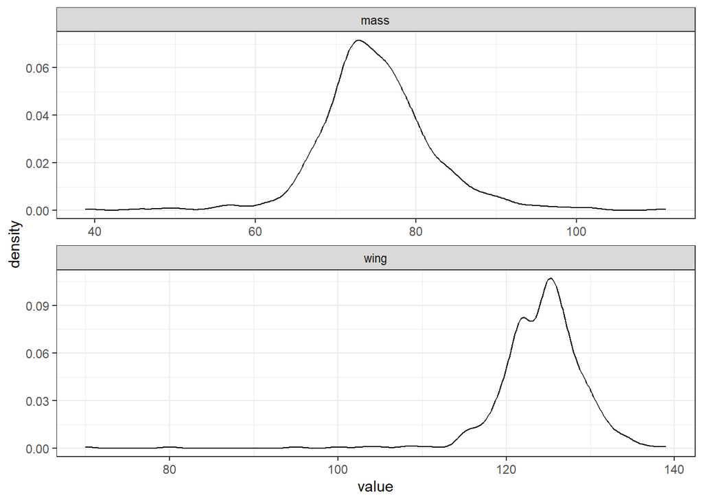

```r
captures %>%
  filter(
    spp == "AMRO") %>%
  select(wing, mass) %>%
  pivot_longer(
    cols = c("wing", "mass")
  ) %>%
  ggplot(mapping = aes(x = value)) +
  geom_density() +
  facet_wrap(~name, scales = "free", nrow = 2) +
  theme_bw()
```

For chained analyses, it is often necessary to visualize the final product of an integrated question *and* the structure of an intermediate product. This question is asking you to generate a facet plot where each facet represents a different variable. Currently, these variables are stored in two separate columns. To make a faceted plot, it will be necessary to arrange both variable *names* in a single column and both sets of variable *values* in another. As such, how would you need to reshape the data?

## Submission

Please save your R markdown (.Rmd) and submit (only) your R markdown (.Rmd) file to Blackboard. *Do not submit the html file!*. After submitting, save the R Markdown file and knitted html to your `output` folder.